# Ford GoBike System Data Flights Exploration

## Data Wrangling

The Ford GoBike System Data Flights includes information about individual rides made in a bike-sharing system covering the greater San Francisco Bay area. We will use the datasets of all the year 2018 which are divided in 12 separated datasets(1 dataset for each month of the year). We will download all the 12 datasets for the year 2018, gather them all together in one unique dataset, assess it and clean it if necessary. First of all let us import libraries useful for the process.

```python
# Import libraries
import numpy as np
import pandas as pd
import seaborn as sb
import matplotlib.pyplot as plt
import requests
import os
import zipfile
import re
import datetime

%matplotlib inline
```

Let us retrieve all the urls from the [Bay Wheels trip history data](https://s3.amazonaws.com/baywheels-data/index.html).

```python
# Create an empty list to store the urls
baywheels_urls = []
# Create a for loop to retrieve the urls one by one, there are 12
for i in range(1,13):
    # Remove the 0 (after 2018) after the 9th file
    if i < 10:
        url = 'https://s3.amazonaws.com/baywheels-data/20180' + str(i) +'-fordgobike-tripdata.csv.zip'
    else:
        url = 'https://s3.amazonaws.com/baywheels-data/2018' + str(i) +'-fordgobike-tripdata.csv.zip'
    baywheels_urls.append(url)
baywheels_urls
```

```
['https://s3.amazonaws.com/baywheels-data/201801-fordgobike-tripdata.csv.zip',
 'https://s3.amazonaws.com/baywheels-data/201802-fordgobike-tripdata.csv.zip',
 'https://s3.amazonaws.com/baywheels-data/201803-fordgobike-tripdata.csv.zip',
 'https://s3.amazonaws.com/baywheels-data/201804-fordgobike-tripdata.csv.zip',
 'https://s3.amazonaws.com/baywheels-data/201805-fordgobike-tripdata.csv.zip',
 'https://s3.amazonaws.com/baywheels-data/201806-fordgobike-tripdata.csv.zip',
 'https://s3.amazonaws.com/baywheels-data/201807-fordgobike-tripdata.csv.zip',
 'https://s3.amazonaws.com/baywheels-data/201808-fordgobike-tripdata.csv.zip',
 'https://s3.amazonaws.com/baywheels-data/201809-fordgobike-tripdata.csv.zip',
 'https://s3.amazonaws.com/baywheels-data/201810-fordgobike-tripdata.csv.zip',
 'https://s3.amazonaws.com/baywheels-data/201811-fordgobike-tripdata.csv.zip',
 'https://s3.amazonaws.com/baywheels-data/201812-fordgobike-tripdata.csv.zip']
```

Now we download all the zip files from the urls and store them in the created folder.

```python
zip_folder = 'baywheels_monthly_data_zip'   # folder to store the zip files
# Create zip_folder if it does not exist
if not os.path.exists(zip_folder):
    os.makedirs(zip_folder)

# Download each zip file from the urls with a for loop
for url in baywheels_urls:
    response = requests.get(url)
    # Retrieve programmatically the name of the file which is the last part after /
    with open(os.path.join(zip_folder, url.split('/')[-1]), mode = 'wb') as file:
        file.write(response.content)
sorted(os.listdir(zip_folder))
```

```
['201801-fordgobike-tripdata.csv.zip',
 '201802-fordgobike-tripdata.csv.zip',
 '201803-fordgobike-tripdata.csv.zip',
 '201804-fordgobike-tripdata.csv.zip',
 '201805-fordgobike-tripdata.csv.zip',
 '201806-fordgobike-tripdata.csv.zip',
 '201807-fordgobike-tripdata.csv.zip',
 '201808-fordgobike-tripdata.csv.zip',
 '201809-fordgobike-tripdata.csv.zip',
 '201810-fordgobike-tripdata.csv.zip',
 '201811-fordgobike-tripdata.csv.zip',
 '201812-fordgobike-tripdata.csv.zip']
```

All the zip files are in the folder, we can proceed and unzip them.

```python
csv_folder = 'baywheels_monthly_data_csv'   # folder to store the unzip csv files
# Create csv_folder
if not os.path.exists(csv_folder):
    os.makedirs(csv_folder)

import glob
files = glob.glob(zip_folder+'/*.zip')
for file in files:
    with zipfile.ZipFile(file, 'r') as my_zip:
        my_zip.extractall(csv_folder)
```

```python
sorted(os.listdir(csv_folder))
```

```
['201801-fordgobike-tripdata.csv',
 '201802-fordgobike-tripdata.csv',
 '201803-fordgobike-tripdata.csv',
 '201804-fordgobike-tripdata.csv',
 '201805-fordgobike-tripdata.csv',
 '201806-fordgobike-tripdata.csv',
 '201807-fordgobike-tripdata.csv',
 '201808-fordgobike-tripdata.csv',
 '201809-fordgobike-tripdata.csv',
 '201810-fordgobike-tripdata.csv',
 '201811-fordgobike-tripdata.csv',
 '201812-fordgobike-tripdata.csv']
```

```python
# Read one file to see if everything is ok
test = pd.read_csv('baywheels_monthly_data_csv/201801-fordgobike-tripdata.csv')
test.shape
print(test.dtypes)
test.sample(6)
```

```
duration_sec                 int64
start_time                  object
end_time                    object
start_station_id             int64
start_station_name          object
start_station_latitude     float64
start_station_longitude    float64
end_station_id               int64
end_station_name            object
end_station_latitude       float64
end_station_longitude      float64
bike_id                      int64
user_type                   object
member_birth_year          float64
member_gender               object
bike_share_for_all_trip     object
dtype: object
```

|  | duration_sec | start_time | end_time | start_station_id | start_station_name | start_station_latitude | start_station_longitude | end_station_id | end_station_name | end_station_latitude | end_station_longitude | bike_id | user_type | member_birth_year | member_gender | bike_share_for_all_trip |
| --- | --- | --- | --- | --- | --- | --- | --- | --- | --- | --- | --- | --- | --- | --- | --- | --- |
| 73961 | 1203 | 2018-01-10 07:37:49.5830 | 2018-01-10 07:57:52.6350 | 72 | Page St at Scott St | 37.772406 | -122.435650 | 19 | Post St at Kearny St | 37.788975 | -122.403452 | 1056 | Subscriber | 1984.0 | Male | No |
| 48274 | 656 | 2018-01-17 21:22:21.9000 | 2018-01-17 21:33:18.0080 | 106 | Sanchez St at 17th St | 37.763242 | -122.430675 | 70 | Central Ave at Fell St | 37.773311 | -122.444293 | 2273 | Subscriber | 1995.0 | Male | No |
| 89825 | 772 | 2018-01-03 07:57:20.1980 | 2018-01-03 08:10:12.7150 | 66 | 3rd St at Townsend St | 37.778742 | -122.392741 | 8 | The Embarcadero at Vallejo St | 37.799953 | -122.398525 | 2998 | Subscriber | 1977.0 | Female | No |
| 60777 | 372 | 2018-01-14 05:00:56.0090 | 2018-01-14 05:07:08.6620 | 313 | Almaden Blvd at San Fernando St | 37.331415 | -121.893200 | 35 | Cahill Park | 37.329119 | -121.904576 | 1859 | Subscriber | 1981.0 | Male | No |
| 61517 | 299 | 2018-01-13 15:55:33.3660 | 2018-01-13 16:00:32.6980 | 150 | Adeline St at 40th St | 37.831277 | -122.278267 | 176 | MacArthur BART Station | 37.828410 | -122.266315 | 3290 | Subscriber | 1989.0 | Male | No |
| 94149 | 61 | 2018-01-01 14:44:37.2870 | 2018-01-01 14:45:38.5430 | 126 | Esprit Park | 37.761634 | -122.390648 | 126 | Esprit Park | 37.761634 | -122.390648 | 68 | Customer | NaN | NaN | No |

Now that we have all the files we can read them and join them together in a unique dataframe.

```python
# Select all the files in the csv_folder and store them in a list
list_files = glob.glob(csv_folder+'/*.csv')
# Read all the files of the list and put them all in one unique file
baywheels_data = pd.concat(map(pd.read_csv, list_files))
```

```python
print(baywheels_data.shape)
print(baywheels_data.dtypes)
baywheels_data.head()
```

```
(1863721, 16)
duration_sec                 int64
start_time                  object
end_time                    object
start_station_id           float64
start_station_name          object
start_station_latitude     float64
start_station_longitude    float64
end_station_id             float64
end_station_name            object
end_station_latitude       float64
end_station_longitude      float64
bike_id                      int64
user_type                   object
member_birth_year          float64
member_gender               object
bike_share_for_all_trip     object
dtype: object
```

|  | duration_sec | start_time | end_time | start_station_id | start_station_name | start_station_latitude | start_station_longitude | end_station_id | end_station_name | end_station_latitude | end_station_longitude | bike_id | user_type | member_birth_year | member_gender | bike_share_for_all_trip |
| --- | --- | --- | --- | --- | --- | --- | --- | --- | --- | --- | --- | --- | --- | --- | --- | --- |
| 0 | 71766 | 2018-03-31 16:58:33.1490 | 2018-04-01 12:54:39.2630 | 4.0 | Cyril Magnin St at Ellis St | 37.785881 | -122.408915 | 6.0 | The Embarcadero at Sansome St | 37.804770 | -122.403234 | 341 | Customer | 1964.0 | Female | No |
| 1 | 62569 | 2018-03-31 19:03:35.9160 | 2018-04-01 12:26:25.0350 | 78.0 | Folsom St at 9th St | 37.773717 | -122.411647 | 47.0 | 4th St at Harrison St | 37.780955 | -122.399749 | 536 | Subscriber | 1984.0 | Male | No |
| 2 | 56221 | 2018-03-31 20:13:13.5640 | 2018-04-01 11:50:14.8400 | 258.0 | University Ave at Oxford St | 37.872355 | -122.266447 | 239.0 | Bancroft Way at Telegraph Ave | 37.868813 | -122.258764 | 3245 | Customer | 1983.0 | Male | No |
| 3 | 85844 | 2018-03-31 11:28:07.6580 | 2018-04-01 11:18:52.6130 | 186.0 | Lakeside Dr at 14th St | 37.801319 | -122.262642 | 340.0 | Harmon St at Adeline St | 37.849735 | -122.270582 | 3722 | Customer | NaN | NaN | No |
| 4 | 1566 | 2018-03-31 23:37:56.6400 | 2018-04-01 00:04:02.8930 | 193.0 | Grand Ave at Santa Clara Ave | 37.812744 | -122.247215 | 196.0 | Grand Ave at Perkins St | 37.808894 | -122.256460 | 2355 | Subscriber | 1979.0 | Male | No |

All the files are in one unique dataframe `baywheels_data`, but there are many issues to fix before using the dataframe. Many columns does not have the correct data type(start_time, end_time, start_station_id,end_station_id, user_type,member_birth_year,member_gender).

```python
# Change the data type of start_time and end_time from object to date_time
baywheels_data.start_time = pd.to_datetime(baywheels_data.start_time, format = '%Y-%m-%d %H:%M:%S.%f')
baywheels_data.end_time = pd.to_datetime(baywheels_data.end_time, format = '%Y-%m-%d %H:%M:%S.%f')
```

```python
# Assert that the changes are correct, no output means it is correct
assert baywheels_data.start_time.dtypes == '<datetime64[ns]'
assert baywheels_data.end_time.dtypes == '<datetime64[ns]'
```

```python
# member_birth_year from float to int, we use Int64 instead of int64 to make it work
baywheels_data.member_birth_year = baywheels_data.member_birth_year.astype('Int64')
```

```python
# Check if the data type is correct, no output means it is correct
assert baywheels_data.member_birth_year.dtypes == 'Int64'
```

```python
# Change the data type of member_gender from string to category
baywheels_data.member_gender = baywheels_data.member_gender.fillna('Other') # Change the NaNs values to other
baywheels_data.member_gender = baywheels_data.member_gender.astype('category')
```

```python
# Check if the data type is correct, no output means it is correct
assert baywheels_data.member_gender.dtypes == 'category'
```

```python
# Change the user type from string to category
baywheels_data.user_type = baywheels_data.user_type.astype('category')
```

```python
# Check the changes, no output means it is correct
assert baywheels_data.user_type.dtypes == 'category'
```

```python
baywheels_data.start_station_id = baywheels_data.start_station_id.fillna(0) # Replace the NaNs values with 0
baywheels_data.end_station_id = baywheels_data.end_station_id.fillna(0)     # Replace the NaNs values with 0
# Change data type of start_station_id and end_station_id from float to int
baywheels_data.start_station_id = baywheels_data.start_station_id.astype(int)
baywheels_data.end_station_id = baywheels_data.end_station_id.astype(int)
```

```python
# Check the changes, no output means it is ok
assert baywheels_data.start_station_id.dtypes == 'int64'
assert baywheels_data.end_station_id.dtypes == 'int64'
```

```python
# Some descriptives statistics for numeric variables
baywheels_data.describe()
```

|  | duration_sec | start_station_id | start_station_latitude | start_station_longitude | end_station_id | end_station_latitude | end_station_longitude | bike_id | member_birth_year |
| --- | --- | --- | --- | --- | --- | --- | --- | --- | --- |
| count | 1.863721e+06 | 1.863721e+06 | 1.863721e+06 | 1.863721e+06 | 1.863721e+06 | 1.863721e+06 | 1.863721e+06 | 1.863721e+06 | 1.753003e+06 |
| mean | 8.573026e+02 | 1.189186e+02 | 3.776678e+01 | -1.223492e+02 | 1.174266e+02 | 3.776690e+01 | -1.223487e+02 | 2.296851e+03 | 1.983088e+03 |
| std | 2.370379e+03 | 1.005281e+02 | 1.057689e-01 | 1.654634e-01 | 1.005593e+02 | 1.056483e-01 | 1.650597e-01 | 1.287733e+03 | 1.044289e+01 |
| min | 6.100000e+01 | 0.000000e+00 | 3.726331e+01 | -1.224737e+02 | 0.000000e+00 | 3.726331e+01 | -1.224737e+02 | 1.100000e+01 | 1.881000e+03 |
| 25% | 3.500000e+02 | 3.000000e+01 | 3.777106e+01 | -1.224114e+02 | 3.000000e+01 | 3.777106e+01 | -1.224094e+02 | 1.225000e+03 | 1.978000e+03 |
| 50% | 5.560000e+02 | 8.800000e+01 | 3.778107e+01 | -1.223974e+02 | 8.700000e+01 | 3.778127e+01 | -1.223971e+02 | 2.338000e+03 | 1.985000e+03 |
| 75% | 8.720000e+02 | 1.830000e+02 | 3.779625e+01 | -1.222865e+02 | 1.830000e+02 | 3.779728e+01 | -1.222894e+02 | 3.333000e+03 | 1.991000e+03 |
| max | 8.636600e+04 | 3.810000e+02 | 4.551000e+01 | -7.357000e+01 | 3.810000e+02 | 4.551000e+01 | -7.357000e+01 | 6.234000e+03 | 2.000000e+03 |

**Structure of the Dataset**  
There are 1863721 rows and 16 variables in the dataset(duration_sec, start_time, end_time, start_station_id, start_station_name, start_station_latitude, start_station_longitude, end_station_id, end_station_name, end_station_latitude, end_station_longitude, bike_id, user_type, member_birth_year, member_gender, bike_share_for_all_trip), 9 of these are numerical variables.

**Main features of interest in the dataset**  
We are more interested in figuring out what factors or features affect the place a trip is taken and the duration of the trips.

**Features That will help support our investigation into our features of interest**  
Probably during the summer and holidays there will be more trip and for more time so the variables start_time and end_time will probably have the major effect on the duration, we can also expect that subscriber takes more trips than customers, we can expect that young people have many trips than old people.

## Univariate Exploration

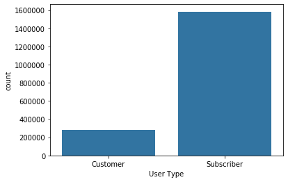

```python
# Plot of the user type
base_color = sb.color_palette()[0]
sb.countplot(data = baywheels_data, x = 'user_type', color = base_color)
plt.xlabel('User Type');
```

As expected all over the year there are more Subscribers than customers.

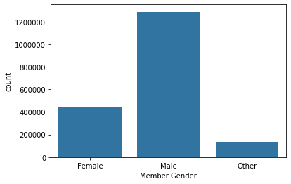

```python
# Plot Member gender
sb.countplot(data = baywheels_data, x = 'member_gender', color = base_color)
plt.xlabel('Member Gender');
```

```python
# Plot of the share bike
```

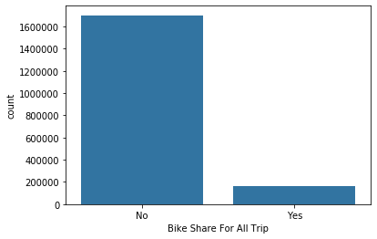

```python
sb.countplot(data = baywheels_data, x = 'bike_share_for_all_trip', color = base_color)
plt.xlabel('Bike Share For All Trip');
```

Over the year just few trips are in the modality "Share for all trip".

All over the year there are More men have trip compared to Women.

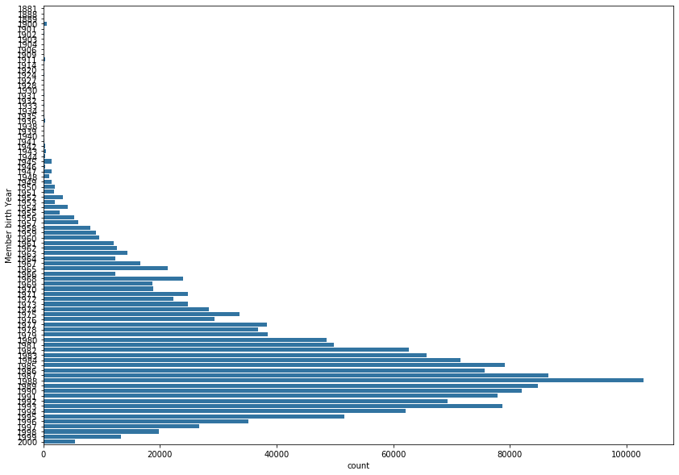

```python
# Plot of the member_birth_year
plt.figure(figsize = (14,10))
sb.countplot(data = baywheels_data, y = 'member_birth_year', color = base_color)
plt.ylabel('Member birth Year');
```

Looking at this plot we figure out that there are many outliers. Let us go deep.

```python
# Check all the member birth year higher than 100 years
wrong_birth_values = baywheels_data[baywheels_data.member_birth_year < 1918].member_birth_year
wrong_birth_values.value_counts().index
```

```
Index([1900, 1911, 1902, 1901, 1888, 1914, 1904, 1881, 1909, 1889, 1906, 1903], dtype='object')
```

All those values are probably errors, the oldest people in the world are around 116 years old and most of them live in Japan, in the other hand [the oldest](https://www.oldest.org/people/living-people-usa/) people in the USA are around 112 years old and are not in a state of driving a bicycle. We will consider in this analysis that all the people with more than 100 years old are wrong values probably due to data entry and turn all these values to NaNs.

```python
# Turn all the member_birth_year wrong values to NaNs
for val in wrong_birth_values.value_counts().index:
    baywheels_data.member_birth_year[baywheels_data.member_birth_year == val] = np.nan
```

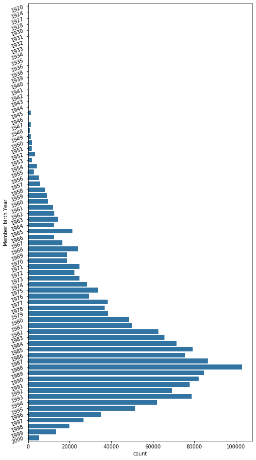

```python
# Change the size of the plot
plt.figure(figsize = (8,16))
# Plot the count of each member birth year
sb.countplot(data = baywheels_data, y = 'member_birth_year', color = base_color)
# label the y axis
plt.ylabel('Member birth Year')
# Rotate the y ticks of 20 degrees for readability
plt.yticks(rotation = 20);
```

```python
# Check if everything is ok
assert wrong_birth_values.value_counts().index.isin(baywheels_data.member_birth_year.tolist()).all() == False
```

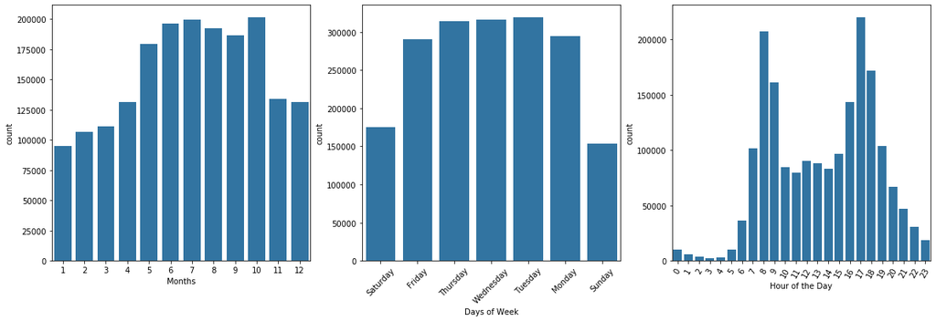

```python
# Change the size of the plots
plt.figure(figsize = [20,6])
# Add the Month plot on row 1 col 1
plt.subplot(1,3,1)
months = pd.DatetimeIndex(baywheels_data.start_time).month
sb.countplot(x = months, color = base_color)
plt.xlabel('Months')
# Add the Days plot on row 1 col 2
plt.subplot(1,3,2)
week_name = pd.DatetimeIndex(baywheels_data.start_time).weekday_name
sb.countplot(x = week_name, color = base_color)
plt.xlabel('Days of Week')
plt.xticks(rotation = 45)
# Add the Hour plot on row 1 col 3
plt.subplot(1,3,3)
hours = pd.DatetimeIndex(baywheels_data.start_time).hour
sb.countplot(x = hours, color = base_color)
plt.xlabel('Hour of the Day')
plt.xticks(rotation = 60);
```

From may(5) to october(10) we have the higher values with the highest at october which means that there are the period of the year 2018 with more trips. These values are a little bit expected in fact we have the highest values during the summer and autumn and the lowest during the winter and spring. In the other hands during the weedays we have the highest values and the lowest during the the weekends.  
There are more trips between 8am and 9am, and between 5pm and 6pm, which is also expected as these time of the day represents the start and the end of the work day. This let us think that the bicybles are more used when the weather is beautiful and during the work days, bicycles are probably more used to go and back from work.

Let us go deep with some descriptive statistic in the duration_sec column.

```python
print('Duration max :', baywheels_data.duration_sec.max())      # Print the duration max over the year
print('Duration min :', baywheels_data.duration_sec.min())      # Print the duration min over the year
print('Average duration:', baywheels_data.duration_sec.mean())  # Print the average duration over the year
```

```
Duration max : 86366
Duration min : 61
Average duration: 857.3025710393348
```

The average duration over the year of a single trip is about **857s** which means around **14mn**, the minimum duration is about 1mn, and the max duration is about **24h** for one single trip.

```python
baywheels_data[baywheels_data.duration_sec == baywheels_data.duration_sec.max()]
```

|  | duration_sec | start_time | end_time | start_station_id | start_station_name | start_station_latitude | start_station_longitude | end_station_id | end_station_name | end_station_latitude | end_station_longitude | bike_id | user_type | member_birth_year | member_gender | bike_share_for_all_trip |
| --- | --- | --- | --- | --- | --- | --- | --- | --- | --- | --- | --- | --- | --- | --- | --- | --- |
| 92914 | 86366 | 2018-02-03 17:32:04.042 | 2018-02-04 17:31:30.788 | 197 | El Embarcadero at Grand Ave | 37.808848 | -122.24968 | 197 | El Embarcadero at Grand Ave | 37.808848 | -122.24968 | 1486 | Customer | NaN | Other | No |

Unexpectedly we have the longest trip(24h) at february by a customer.

```python
min_df = baywheels_data[baywheels_data.duration_sec == baywheels_data.duration_sec.min()]
min_df
```

|  | duration_sec | start_time | end_time | start_station_id | start_station_name | start_station_latitude | start_station_longitude | end_station_id | end_station_name | end_station_latitude | end_station_longitude | bike_id | user_type | member_birth_year | member_gender | bike_share_for_all_trip |
| --- | --- | --- | --- | --- | --- | --- | --- | --- | --- | --- | --- | --- | --- | --- | --- | --- |
| 13644 | 61 | 2018-03-28 19:11:30.722 | 2018-03-28 19:12:31.898 | 6 | The Embarcadero at Sansome St | 37.804770 | -122.403234 | 6 | The Embarcadero at Sansome St | 37.804770 | -122.403234 | 3690 | Subscriber | 1952 | Male | No |
| 49055 | 61 | 2018-03-19 17:49:55.948 | 2018-03-19 17:50:57.564 | 162 | Franklin St at 9th St | 37.800516 | -122.272080 | 162 | Franklin St at 9th St | 37.800516 | -122.272080 | 3094 | Subscriber | 1985 | Male | Yes |
| 49143 | 61 | 2018-03-19 17:42:56.834 | 2018-03-19 17:43:58.801 | 162 | Franklin St at 9th St | 37.800516 | -122.272080 | 162 | Franklin St at 9th St | 37.800516 | -122.272080 | 3094 | Subscriber | 1985 | Male | Yes |
| 49156 | 61 | 2018-03-19 17:41:40.062 | 2018-03-19 17:42:41.637 | 162 | Franklin St at 9th St | 37.800516 | -122.272080 | 162 | Franklin St at 9th St | 37.800516 | -122.272080 | 3094 | Subscriber | 1985 | Male | Yes |
| 49183 | 61 | 2018-03-19 17:38:55.690 | 2018-03-19 17:39:57.490 | 162 | Franklin St at 9th St | 37.800516 | -122.272080 | 162 | Franklin St at 9th St | 37.800516 | -122.272080 | 3094 | Subscriber | 1985 | Male | Yes |
| 49204 | 61 | 2018-03-19 17:37:38.232 | 2018-03-19 17:38:39.390 | 162 | Franklin St at 9th St | 37.800516 | -122.272080 | 162 | Franklin St at 9th St | 37.800516 | -122.272080 | 3094 | Subscriber | 1985 | Male | Yes |
| 76044 | 61 | 2018-03-11 14:13:35.274 | 2018-03-11 14:14:37.174 | 28 | The Embarcadero at Bryant St | 37.787168 | -122.388098 | 28 | The Embarcadero at Bryant St | 37.787168 | -122.388098 | 3043 | Customer | 1989 | Male | No |
| 97666 | 61 | 2018-03-06 07:38:08.811 | 2018-03-06 07:39:10.134 | 281 | 9th St at San Fernando | 37.338395 | -121.880797 | 280 | San Fernando at 7th St | 37.337246 | -121.883074 | 3087 | Subscriber | 1990 | Male | Yes |
| 101517 | 61 | 2018-03-05 08:55:31.818 | 2018-03-05 08:56:33.591 | 113 | Franklin Square | 37.764555 | -122.410345 | 100 | Bryant St at 15th St | 37.767100 | -122.410662 | 714 | Subscriber | 1989 | Male | No |
| 103765 | 61 | 2018-03-04 11:56:54.371 | 2018-03-04 11:57:55.814 | 21 | Montgomery St BART Station (Market St at 2nd St) | 37.789625 | -122.400811 | 21 | Montgomery St BART Station (Market St at 2nd St) | 37.789625 | -122.400811 | 2007 | Subscriber | 1971 | Male | No |
| 103902 | 61 | 2018-03-04 11:04:57.271 | 2018-03-04 11:05:59.024 | 317 | San Salvador St at 9th St | 37.333955 | -121.877349 | 317 | San Salvador St at 9th St | 37.333955 | -121.877349 | 1809 | Customer | 1997 | Male | No |
| 107064 | 61 | 2018-03-02 14:28:56.330 | 2018-03-02 14:29:58.262 | 202 | Washington St at 8th St | 37.800754 | -122.274894 | 202 | Washington St at 8th St | 37.800754 | -122.274894 | 2264 | Subscriber | 1950 | Male | No |
| 39589 | 61 | 2018-01-20 18:16:55.980 | 2018-01-20 18:17:57.336 | 146 | 30th St at San Jose Ave | 37.742314 | -122.423180 | 146 | 30th St at San Jose Ave | 37.742314 | -122.423180 | 1722 | Subscriber | 1968 | Female | No |
| 65529 | 61 | 2018-01-12 10:02:05.213 | 2018-01-12 10:03:06.553 | 243 | Bancroft Way at College Ave | 37.869360 | -122.254337 | 239 | Bancroft Way at Telegraph Ave | 37.868813 | -122.258764 | 30 | Subscriber | 1996 | Male | Yes |
| 67162 | 61 | 2018-01-11 19:32:10.782 | 2018-01-11 19:33:12.118 | 133 | Valencia St at 22nd St | 37.755213 | -122.420975 | 134 | Valencia St at 24th St | 37.752428 | -122.420628 | 3184 | Subscriber | 1988 | Male | No |
| 72961 | 61 | 2018-01-10 10:02:22.774 | 2018-01-10 10:03:24.196 | 30 | San Francisco Caltrain (Townsend St at 4th St) | 37.776598 | -122.395282 | 30 | San Francisco Caltrain (Townsend St at 4th St) | 37.776598 | -122.395282 | 2666 | Subscriber | 1958 | Male | No |
| 76122 | 61 | 2018-01-09 14:40:29.651 | 2018-01-09 14:41:31.206 | 153 | 59th St at Horton St | 37.840945 | -122.291360 | 153 | 59th St at Horton St | 37.840945 | -122.291360 | 307 | Subscriber | 1977 | Male | No |
| 79005 | 61 | 2018-01-07 17:15:01.495 | 2018-01-07 17:16:03.217 | 125 | 20th St at Bryant St | 37.759200 | -122.409851 | 129 | Harrison St at 20th St | 37.758862 | -122.412544 | 3305 | Subscriber | 1969 | Male | Yes |
| 81143 | 61 | 2018-01-06 13:41:52.392 | 2018-01-06 13:42:53.517 | 40 | Laguna St at McAllister St | 37.779208 | -122.426829 | 40 | Laguna St at McAllister St | 37.779208 | -122.426829 | 1648 | Customer | NaN | Other | No |
| 94149 | 61 | 2018-01-01 14:44:37.287 | 2018-01-01 14:45:38.543 | 126 | Esprit Park | 37.761634 | -122.390648 | 126 | Esprit Park | 37.761634 | -122.390648 | 68 | Customer | NaN | Other | No |
| 27670 | 61 | 2018-12-21 16:22:28.638 | 2018-12-21 16:23:29.897 | 357 | 2nd St at Julian St | 37.341132 | -121.892844 | 357 | 2nd St at Julian St | 37.341132 | -121.892844 | 3886 | Subscriber | 1994 | Male | Yes |
| 31064 | 61 | 2018-12-20 20:11:49.298 | 2018-12-20 20:12:50.828 | 160 | West Oakland BART Station | 37.805318 | -122.294837 | 160 | West Oakland BART Station | 37.805318 | -122.294837 | 2927 | Subscriber | 1973 | Female | No |
| 46979 | 61 | 2018-12-18 14:49:14.299 | 2018-12-18 14:50:15.825 | 81 | Berry St at 4th St | 37.775880 | -122.393170 | 81 | Berry St at 4th St | 37.775880 | -122.393170 | 2831 | Customer | 1992 | Male | No |
| 50584 | 61 | 2018-12-17 22:16:28.145 | 2018-12-17 22:17:29.849 | 10 | Washington St at Kearny St | 37.795393 | -122.404770 | 13 | Commercial St at Montgomery St | 37.794231 | -122.402923 | 873 | Subscriber | 1975 | Male | No |
| 54276 | 61 | 2018-12-17 13:30:22.725 | 2018-12-17 13:31:23.769 | 15 | San Francisco Ferry Building (Harry Bridges Pl... | 37.795392 | -122.394203 | 16 | Steuart St at Market St | 37.794130 | -122.394430 | 3402 | Subscriber | 1975 | Male | No |
| 61798 | 61 | 2018-12-15 10:52:06.898 | 2018-12-15 10:53:08.307 | 371 | Lombard St at Columbus Ave | 37.802746 | -122.413579 | 371 | Lombard St at Columbus Ave | 37.802746 | -122.413579 | 5353 | Customer | 1993 | Male | No |
| 62246 | 61 | 2018-12-15 06:48:36.721 | 2018-12-15 06:49:37.745 | 133 | Valencia St at 22nd St | 37.755213 | -122.420975 | 133 | Valencia St at 22nd St | 37.755213 | -122.420975 | 4450 | Subscriber | 1961 | Male | Yes |
| 68754 | 61 | 2018-12-13 20:18:02.962 | 2018-12-13 20:19:04.509 | 125 | 20th St at Bryant St | 37.759200 | -122.409851 | 125 | 20th St at Bryant St | 37.759200 | -122.409851 | 4451 | Subscriber | 1987 | Male | No |
| 69015 | 61 | 2018-12-13 19:24:42.513 | 2018-12-13 19:25:44.241 | 122 | 19th St at Mission St | 37.760299 | -122.418892 | 121 | Mission Playground | 37.759210 | -122.421339 | 5381 | Subscriber | 1978 | Male | No |
| 96313 | 61 | 2018-12-08 15:05:56.146 | 2018-12-08 15:06:57.754 | 75 | Market St at Franklin St | 37.773793 | -122.421239 | 59 | S Van Ness Ave at Market St | 37.774814 | -122.418954 | 2165 | Subscriber | 1931 | Male | No |
| ... | ... | ... | ... | ... | ... | ... | ... | ... | ... | ... | ... | ... | ... | ... | ... | ... |
| 14565 | 61 | 2018-10-30 07:08:46.959 | 2018-10-30 07:09:48.368 | 282 | Market St at Park St | 37.332426 | -121.890349 | 282 | Market St at Park St | 37.332426 | -121.890349 | 141 | Subscriber | 1974 | Male | No |
| 15552 | 61 | 2018-10-29 19:48:33.310 | 2018-10-29 19:49:35.241 | 243 | Bancroft Way at College Ave | 37.869360 | -122.254337 | 239 | Bancroft Way at Telegraph Ave | 37.868813 | -122.258764 | 990 | Subscriber | 1997 | Male | No |
| 24583 | 61 | 2018-10-28 11:14:53.504 | 2018-10-28 11:15:55.499 | 280 | 6th St at San Fernando St (Temporary Location) | 37.337038 | -121.884125 | 310 | San Fernando St at 4th St | 37.335885 | -121.885660 | 72 | Subscriber | 1985 | Male | No |
| 24603 | 61 | 2018-10-28 11:07:04.578 | 2018-10-28 11:08:06.543 | 280 | 6th St at San Fernando St (Temporary Location) | 37.337038 | -121.884125 | 310 | San Fernando St at 4th St | 37.335885 | -121.885660 | 779 | Subscriber | 1985 | Male | No |
| 36963 | 61 | 2018-10-25 19:55:09.330 | 2018-10-25 19:56:10.536 | 67 | San Francisco Caltrain Station 2 (Townsend St... | 37.776639 | -122.395526 | 67 | San Francisco Caltrain Station 2 (Townsend St... | 37.776639 | -122.395526 | 3108 | Subscriber | 1975 | Male | Yes |
| 36975 | 61 | 2018-10-25 19:52:53.986 | 2018-10-25 19:53:55.406 | 67 | San Francisco Caltrain Station 2 (Townsend St... | 37.776639 | -122.395526 | 67 | San Francisco Caltrain Station 2 (Townsend St... | 37.776639 | -122.395526 | 3108 | Subscriber | 1975 | Male | Yes |
| 37003 | 61 | 2018-10-25 19:49:30.539 | 2018-10-25 19:50:31.686 | 67 | San Francisco Caltrain Station 2 (Townsend St... | 37.776639 | -122.395526 | 67 | San Francisco Caltrain Station 2 (Townsend St... | 37.776639 | -122.395526 | 3108 | Subscriber | 1975 | Male | Yes |
| 44271 | 61 | 2018-10-24 19:52:36.289 | 2018-10-24 19:53:38.077 | 67 | San Francisco Caltrain Station 2 (Townsend St... | 37.776639 | -122.395526 | 67 | San Francisco Caltrain Station 2 (Townsend St... | 37.776639 | -122.395526 | 3732 | Subscriber | 1975 | Male | Yes |
| 51904 | 61 | 2018-10-23 20:16:45.683 | 2018-10-23 20:17:47.419 | 67 | San Francisco Caltrain Station 2 (Townsend St... | 37.776639 | -122.395526 | 67 | San Francisco Caltrain Station 2 (Townsend St... | 37.776639 | -122.395526 | 4435 | Subscriber | 1975 | Male | Yes |
| 58372 | 61 | 2018-10-23 07:20:21.354 | 2018-10-23 07:21:22.445 | 37 | 2nd St at Folsom St | 37.785000 | -122.395936 | 37 | 2nd St at Folsom St | 37.785000 | -122.395936 | 1812 | Subscriber | 1975 | Male | Yes |
| 59335 | 61 | 2018-10-22 19:59:28.172 | 2018-10-22 20:00:29.890 | 67 | San Francisco Caltrain Station 2 (Townsend St... | 37.776639 | -122.395526 | 67 | San Francisco Caltrain Station 2 (Townsend St... | 37.776639 | -122.395526 | 2310 | Subscriber | 1975 | Male | Yes |
| 59341 | 61 | 2018-10-22 19:58:20.426 | 2018-10-22 19:59:21.730 | 67 | San Francisco Caltrain Station 2 (Townsend St... | 37.776639 | -122.395526 | 67 | San Francisco Caltrain Station 2 (Townsend St... | 37.776639 | -122.395526 | 2310 | Subscriber | 1975 | Male | Yes |
| 62859 | 61 | 2018-10-22 12:34:51.586 | 2018-10-22 12:35:53.441 | 296 | 5th St at Virginia St | 37.325998 | -121.877120 | 296 | 5th St at Virginia St | 37.325998 | -121.877120 | 1726 | Subscriber | 1993 | Male | Yes |
| 64203 | 61 | 2018-10-22 09:02:23.431 | 2018-10-22 09:03:24.724 | 55 | Webster St at Grove St | 37.777053 | -122.429558 | 55 | Webster St at Grove St | 37.777053 | -122.429558 | 2914 | Subscriber | 1974 | Female | No |
| 65309 | 61 | 2018-10-22 07:41:36.208 | 2018-10-22 07:42:37.821 | 15 | San Francisco Ferry Building (Harry Bridges Pl... | 37.795392 | -122.394203 | 15 | San Francisco Ferry Building (Harry Bridges Pl... | 37.795392 | -122.394203 | 2490 | Subscriber | 1961 | Male | No |
| 73958 | 61 | 2018-10-19 19:26:07.628 | 2018-10-19 19:27:09.473 | 8 | The Embarcadero at Vallejo St | 37.799953 | -122.398525 | 8 | The Embarcadero at Vallejo St | 37.799953 | -122.398525 | 3574 | Customer | NaN | Other | No |
| 93707 | 61 | 2018-10-17 09:10:08.647 | 2018-10-17 09:11:09.887 | 84 | Duboce Park | 37.769201 | -122.433812 | 84 | Duboce Park | 37.769201 | -122.433812 | 593 | Customer | 1991 | Female | No |
| 96017 | 61 | 2018-10-16 20:56:12.493 | 2018-10-16 20:57:13.959 | 81 | Berry St at 4th St | 37.775880 | -122.393170 | 81 | Berry St at 4th St | 37.775880 | -122.393170 | 3653 | Subscriber | 1975 | Male | Yes |
| 96026 | 61 | 2018-10-16 20:53:54.988 | 2018-10-16 20:54:56.444 | 81 | Berry St at 4th St | 37.775880 | -122.393170 | 81 | Berry St at 4th St | 37.775880 | -122.393170 | 3653 | Subscriber | 1975 | Male | Yes |
| 99264 | 61 | 2018-10-16 15:33:00.272 | 2018-10-16 15:34:01.730 | 0 | NaN | 37.410000 | -121.940000 | 0 | NaN | 37.410000 | -121.940000 | 4167 | Customer | 1997 | Male | No |
| 104480 | 61 | 2018-10-15 19:09:53.459 | 2018-10-15 19:10:55.137 | 132 | 24th St at Chattanooga St | 37.751819 | -122.426614 | 138 | Jersey St at Church St | 37.750900 | -122.427411 | 3589 | Subscriber | 1988 | Male | No |
| 126804 | 61 | 2018-10-11 19:37:18.595 | 2018-10-11 19:38:20.163 | 67 | San Francisco Caltrain Station 2 (Townsend St... | 37.776639 | -122.395526 | 67 | San Francisco Caltrain Station 2 (Townsend St... | 37.776639 | -122.395526 | 486 | Subscriber | 1975 | Male | Yes |
| 141015 | 61 | 2018-10-09 22:29:15.062 | 2018-10-09 22:30:16.936 | 310 | San Fernando St at 4th St | 37.335885 | -121.885660 | 310 | San Fernando St at 4th St | 37.335885 | -121.885660 | 1444 | Subscriber | 1993 | Male | Yes |
| 145308 | 61 | 2018-10-09 12:16:58.331 | 2018-10-09 12:17:59.519 | 102 | Irwin St at 8th St | 37.766883 | -122.399579 | 345 | Hubbell St at 16th St | 37.766474 | -122.398295 | 1848 | Subscriber | 1980 | Male | No |
| 159153 | 61 | 2018-10-07 10:52:03.030 | 2018-10-07 10:53:04.773 | 88 | 11th St at Bryant St | 37.770030 | -122.411726 | 88 | 11th St at Bryant St | 37.770030 | -122.411726 | 3571 | Subscriber | 1989 | Male | No |
| 161284 | 61 | 2018-10-06 16:27:31.647 | 2018-10-06 16:28:33.026 | 42 | San Francisco City Hall (Polk St at Grove St) | 37.778650 | -122.418230 | 42 | San Francisco City Hall (Polk St at Grove St) | 37.778650 | -122.418230 | 1152 | Customer | NaN | Other | No |
| 161551 | 61 | 2018-10-06 15:42:58.526 | 2018-10-06 15:44:00.275 | 107 | 17th St at Dolores St | 37.763015 | -122.426497 | 120 | Mission Dolores Park | 37.761420 | -122.426435 | 145 | Subscriber | 1993 | Male | No |
| 177355 | 61 | 2018-10-04 09:01:29.529 | 2018-10-04 09:02:30.917 | 73 | Pierce St at Haight St | 37.771793 | -122.433708 | 73 | Pierce St at Haight St | 37.771793 | -122.433708 | 1651 | Customer | 1996 | Female | No |
| 178679 | 61 | 2018-10-04 07:09:16.583 | 2018-10-04 07:10:18.178 | 72 | Page St at Scott St | 37.772406 | -122.435650 | 73 | Pierce St at Haight St | 37.771793 | -122.433708 | 3744 | Subscriber | 1986 | Male | No |
| 180238 | 61 | 2018-10-03 19:05:42.324 | 2018-10-03 19:06:44.126 | 25 | Howard St at 2nd St | 37.787522 | -122.397405 | 25 | Howard St at 2nd St | 37.787522 | -122.397405 | 3816 | Subscriber | 1980 | Male | No |

251 rows × 16 columns

```python
min_df.shape
```

```
(251, 16)
```

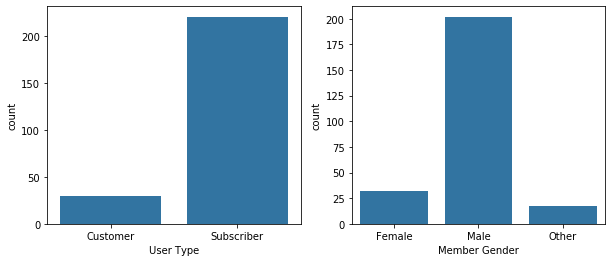

```python
plt.figure(figsize = [10,4])
plt.subplot(1,2,1)
sb.countplot(data = min_df, x = 'user_type', color = base_color)
plt.xlabel('User Type');
plt.subplot(1,2,2)
sb.countplot(data = min_df, x = 'member_gender', color = base_color)
plt.xlabel('Member Gender');
```

There 251 trips with the minimum duration of 61s, of which 221 are made by subscribers and just 30 by customers. As we can expect most of the users are Men.

**Durations with the max number of trips**

```python
# Calucalate the duration groups(too slow with for loop, better use list comprehension)
baywheels_data['duration_groups'] = ['0-15mn' if duration <=900 else '15-30mn' if duration <= 1800 else
                                     '30-60mn' if duration <= 3600 else '1-5h' if duration <=18000 else
                                     '5-12h' if duration < 43200 else '12h++'
                                     for duration in baywheels_data.duration_sec]
```

```python
baywheels_data[['duration_sec', 'duration_groups']].sample(5)
```

|  | duration_sec | duration_groups |
| --- | --- | --- |
| 181776 | 853 | 0-15mn |
| 47510 | 232 | 0-15mn |
| 47187 | 287 | 0-15mn |
| 89433 | 736 | 0-15mn |
| 3496 | 528 | 0-15mn |

```python
# Turn the new created columns into category
baywheels_data.duration_groups = pd.Categorical(baywheels_data.duration_groups, ordered = True, categories = ('0-15mn', '15-30mn','30-60mn', '1-5h', '5-12h','12h++'))
```

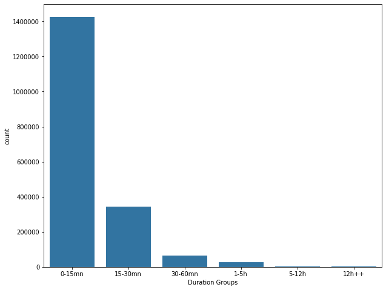

```python
# Plot the differents group
plt.figure(figsize = [10,8])
sb.countplot(data = baywheels_data, x = 'duration_groups', color = base_color)
plt.xlabel('Duration Groups');
```

There are more trip of less than 15mn, which means that in general and over the year all the trips are brief.

**15 *start* and *end* stations with the highest number of trips**

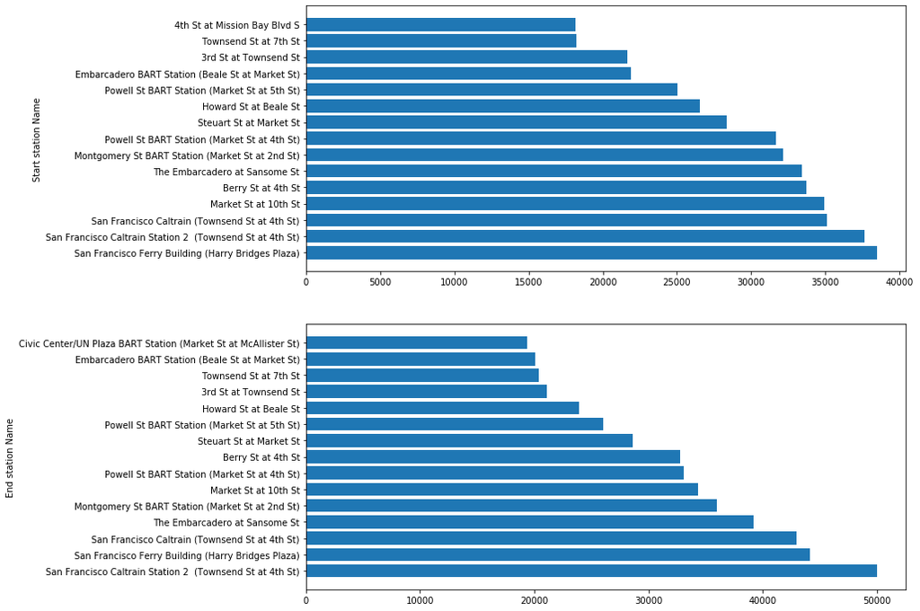

```python
# Plot top 15 stations with the highest number of trip over the year
plt.figure(figsize = [12,12])
# Retrieve the 15 start stations counts
start_counts = baywheels_data.start_station_name.value_counts()[:15]
# Retrieve the 15 start stations names
start_names = baywheels_data.start_station_name.value_counts()[:15].index
# Retrieve the 15 end stations counts
end_counts = baywheels_data.end_station_name.value_counts()[:15]
# Retrieve the 15 end stations names
end_names = baywheels_data.end_station_name.value_counts()[:15].index
# Plot the 15 start stations in the first subplot
plt.subplot(2,1,1)
y_position = np.arange(len(start_names))
plt.barh(y_position, start_counts, align = 'center')
plt.yticks(y_position, start_names)
plt.ylabel('Start station Name')
# Plot the 15 start stations in the second subplot
plt.subplot(2,1,2)
y_position = np.arange(len(end_names))
plt.barh(y_position, end_counts, align = 'center')
plt.yticks(y_position, end_names)
plt.ylabel('End station Name');
```

```python
baywheels_data.start_station_name.value_counts().head(15)[baywheels_data.start_station_name.value_counts()
                                                          .head(15).index.isin(baywheels_data.end_station_name
                                                          .value_counts().head(15).index)==False]
```

```
4th St at Mission Bay Blvd S    18150
Name: start_station_name, dtype: int64
```

Just one station(4th St at Mission Bay Blvd S)are not in either list(start and end) of the 15 stations with the highest trip, so the other 14 even if in different order are the same in start and end.

**15 start and end stations with the lowest number of trips**

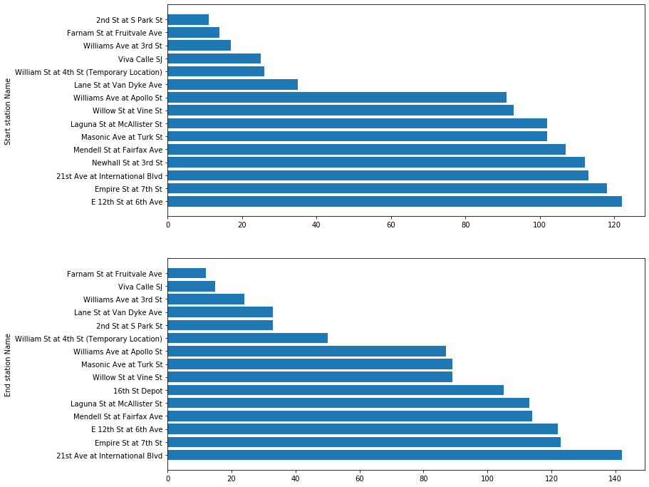

```python
# Plot top 15 stations with the lowest number of trips over the year

plt.figure(figsize = [12,12])
# Retrieve the 15 start stations counts
start_counts_2 = baywheels_data.start_station_name.value_counts().tail(15)
# Retrieve the 15 start stations names
start_names_2 = baywheels_data.start_station_name.value_counts().tail(15).index
# Retrieve the 15 end stations counts
end_counts_2 = baywheels_data.end_station_name.value_counts().tail(15)
# Retrieve the 15 end stations names
end_names_2 = baywheels_data.end_station_name.value_counts().tail(15).index
# Plot the 15 start stations in the first subplot
plt.subplot(2,1,1)
y_position = np.arange(len(start_names_2))
plt.barh(y_position, start_counts_2, align = 'center')
plt.yticks(y_position, start_names_2)
plt.ylabel('Start station Name')
# Plot the 15 start stations in the second subplot
plt.subplot(2,1,2)
y_position = np.arange(len(end_names_2))
plt.barh(y_position, end_counts_2, align = 'center')
plt.yticks(y_position, end_names_2)
plt.ylabel('End station Name');
```

```python
# Stations that are not in lowest 15 start and end
baywheels_data.start_station_name.value_counts().tail(15)[baywheels_data.start_station_name.value_counts()
                                                          .tail(15).index.isin(baywheels_data.end_station_name
                                                          .value_counts().tail(15).index)==False]
```

```
Newhall St at 3rd St    112
Name: start_station_name, dtype: int64
```

## Bivariate Exploration

Let us see if there is a correlation between the numerics variables.

```python
# Put all the numeric variables in a list
numeric_vars = ['duration_sec', 'start_station_id', 'end_station_id', 'bike_id', 'member_birth_year']
# Put all the categorical variables in a list
categoric_vars = ['member_gender', 'user_type', 'bike_share_for_all_trip']
```

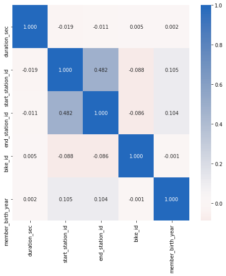

```python
# Change the size plot
plt.figure(figsize = [8,8])
# Plot the heatmap with the correlations
sb.heatmap(baywheels_data[numeric_vars].corr(), annot = True, fmt = '.3f', cmap = 'vlag_r', center = 0);
```

As we could expected there is no correlation between all the ids variables and the duration of the trip, there is no correlation between the member birth year and the duration of the trip, but thinking about it, it is probably due to the fact that even if these variables these variables are numeric they are to consider categorical, for example the bike_id is a unique value given to each bike to identify it.

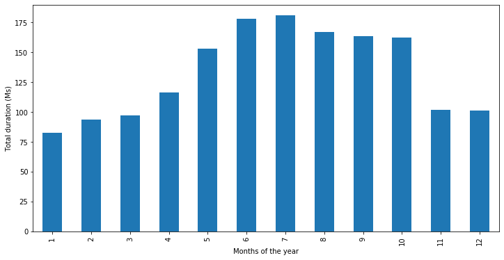

```python
# Plot the total duration of the trip each month
plt.figure(figsize = [12,6])
duration_per_hour = baywheels_data.groupby(months).sum().duration_sec/1e6 # Divide by 1e6 to have it in Mega seconds
duration_per_hour.plot(kind = 'bar')
plt.xlabel('Months of the year')
plt.ylabel('Total duration (Ms)');
```

We have the peaks at june and july. From may to october we have a total duration per month higher than **125 Mega seconds** which means more than **34722** hours.

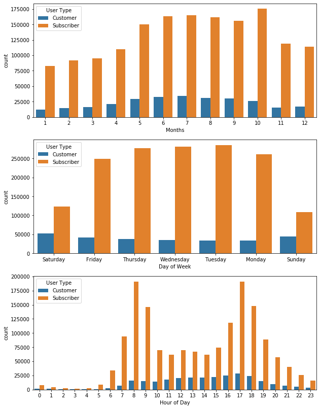

```python
# Plot months of the year vs user_type
plt.figure(figsize = [10,14])
# Subplot months vs user type
plt.subplot(3,1,1)
sb.countplot(data = baywheels_data, x = months, hue = 'user_type')
plt.xlabel('Months')
plt.legend(title = 'User Type', loc = 'upper left')
# Subplot day of week vs user type
plt.subplot(3,1,2)
sb.countplot(data = baywheels_data, x = week_name, hue = 'user_type')
plt.xlabel('Day of Week')
plt.legend(title = 'User Type')
# Subplot hour of day  vs user type
plt.subplot(3,1,3)
sb.countplot(data = baywheels_data, x = hours, hue = 'user_type')
plt.xlabel('Hour of Day')
plt.legend(title = 'User Type', loc = 'upper left');
```

`Subcribers` and `Customers` do not follow the same pattern, for example there are more trips of `Customers` at july and during the weekends, when for `Subscribers` this occur at october and during the weekdays.  
During the day Customers have more trips between 11am and 6pm while for `Subscribers` this happen between 7am to 9am and 4pm to 9pm.

## Multivariate Exploration

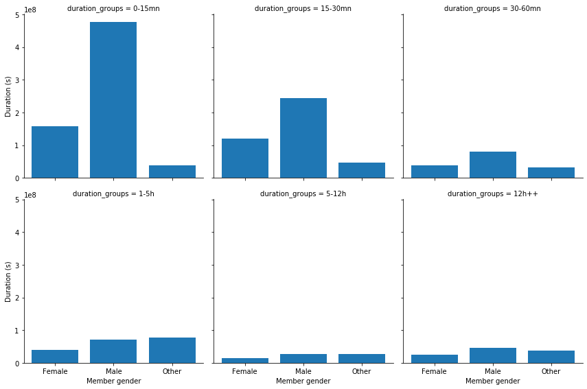

```python
# Group by duration group and member gender then sum the duration sec, reset index to have a dataframe
gender_duration_group = baywheels_data.groupby(['duration_groups','member_gender']).sum().duration_sec.reset_index()
# Facet per duration Groups
g = sb.FacetGrid(data = gender_duration_group, col = 'duration_groups', height = 4, col_wrap = 3)
g.map(plt.bar, 'member_gender', 'duration_sec')
g.set_xlabels('Member gender')
g.set_ylabels('Duration (s)');
```

In general Woman have less trip duration than Man no matter the group of duration.The Other category in the group of duration 1-5 hours has more duration time than the Male and Female categories.

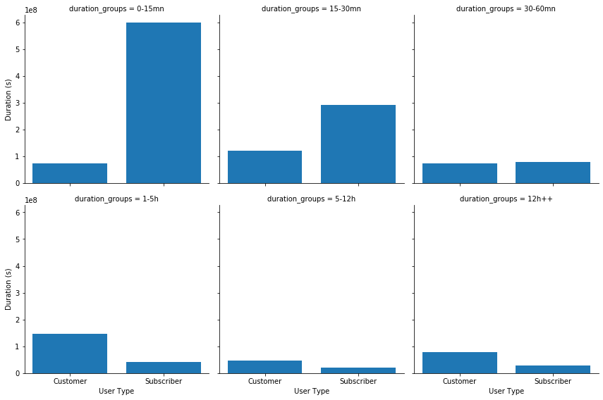

```python
# Group by duration and user type then calculate the total duration for the group and reset index to have df
user_duration_group = baywheels_data.groupby(['duration_groups','user_type']).sum().duration_sec.reset_index()
# Facet per duration Groups
g = sb.FacetGrid(data = user_duration_group, col = 'duration_groups', height = 4, col_wrap = 3)
g.map(plt.bar, 'user_type', 'duration_sec')
g.set_xlabels('User Type')
g.set_ylabels('Duration (s)');
```

Subscribers tend to have brief trips(less than 1 hour) than Customers, in fact from 1h to more than 12 hours Customers have a total duration trip higher than Subscribers.